# Vaccination program

Lộc

2023-09-16

## 1.Gọi các packages trong R:

Nếu bạn không có trong thư viện R thì hãy tải xuống bằng hàm `install.package("names of package")`.

```r
knitr::opts_chunk$set(echo = TRUE)
pacman::p_load(rio,
               here,
               janitor,
               tidyverse,
               dplyr,
               magrittr,
               lubridate,
               stringr,
               viridis
               )
```

## 2.Xây dựng hàm để lập kế hoạch phân phối hàng hóa:

Gỉa sử ta cần nhập 500000 vaccine vào Warehouse để tiêm cho 500000 người ở địa phương. Mỗi lần chỉ nhập được 10000 vaccine và cần 6 ngày mới vận chuyển được tới kho. Vậy hoạt động quản lí tồn kho sẽ diễn ra như thể nào. Ta cần trả lời các câu hỏi như:

- Số lượng vaccine dư thừa là bao nhiêu.
- Có ngày nào người dân phải chờ để tiêm hay không?
- Bao nhiêu ngày bị stock out?

```r
set.seed(123)
Q = 10000 #1000 vaccine will be delivered after 6 days.
N = 500000 #There are 500000 Pfizer vaccine
D = 6 #6 days for the vaccine is delivered from DC to Warehouse in hospitals.
P = rbeta(500,4,12)*4000 #Simulate the numbers of people come to each day equal the numbers of vaccine is daily used

#Function for calculate ending and opening inventory for each day:
#Input:
Order = P
I_start <- rep(NA,501 )
stockOut <- rep(NA, 500)
SP <- rep (NA, 500)
I_end <- rep(NA,500)

I_start[1] <- 0
Date <- seq(as.Date("2023-09-18"),as.Date("2025-01-30"),1)

#Function:
#Schedule the plan for supply the vaccine:
#Because we supply 10000 vaccine in 1 trip for 6 days so we just need 300 days to complete the delivery of 500000 vaccine into warehouse. All next day, SP will be zero.
n = 1
SP = 0
while(sum(SP)%/%1 <= 500000){
      SP[n] <-ifelse(as.numeric(difftime(Date[n],Date[1]))%%6 == 0,
                     10000,
                     0)

      #update expression:
      n = n + 1
    }
SP<-c(SP,rep(0,length(Order)-length(SP)))

#
for (t in 1:500)
{
  if(I_start[t] < Order[t])
  {
    stockOut[t] <- 1
    I_end[t] <- I_start[t] - Order[t]
    I_start[t+1]<-I_end[t]+SP[t]

  }else{
    stockOut[t] <- 0
    I_end[t] <- I_start[t] - Order[t]
    I_start[t+1] <- I_end[t]+SP[t]}

  inventory_df<-data.frame(Date[-1],Order,I_start[-1],I_end,SP,stockOut)
  }
DT::datatable(inventory_df,
              filter = "top",
              option = list(pagelength = 5,
                            scrollX = T))
```

|  | Date..1. | Order | I_start..1. | I_end | SP | stockOut |
| --- | --- | --- | --- | --- | --- | --- |
| 1 | 2023-09-19 | 742.8508315508465 | 9257.149168449154 | -742.8508315508465 | 10000 | 1 |
| 2 | 2023-09-20 | 888.9739987247625 | 8368.17516972439 | 8368.17516972439 | 0 | 0 |
| 3 | 2023-09-21 | 2055.90159266652 | 6312.273577057871 | 6312.273577057871 | 0 | 0 |
| 4 | 2023-09-22 | 1035.723183511898 | 5276.550393545974 | 5276.550393545974 | 0 | 0 |
| 5 | 2023-09-23 | 1066.167214996446 | 4210.383178549528 | 4210.383178549528 | 0 | 0 |
| 6 | 2023-09-24 | 1250.437783170321 | 2959.945395379207 | 2959.945395379207 | 0 | 0 |
| 7 | 2023-09-25 | 474.985181473143 | 12484.96021390606 | 2484.960213906064 | 10000 | 0 |
| 8 | 2023-09-26 | 690.5953684897235 | 11794.36484541634 | 11794.36484541634 | 0 | 0 |
| 9 | 2023-09-27 | 792.0214777680283 | 11002.34336764831 | 11002.34336764831 | 0 | 0 |
| 10 | 2023-09-28 | 1774.999051357635 | 9227.344316290679 | 9227.344316290679 | 0 | 0 |

[output cut: 490 more lines]

## 3.Xây dựng hàm để simulate mô hình tiêm chích:

Mỗi ngày sẽ có n người đến để tiêm chích (P là phân phối số người đến tiêm trong 500 ngày). Ý tưởng để xây dựng hàm là làm 2 vòng lặp:  
-1 vòng để tính các chỉ số về service time, waiting time, arrival time, leaving time cho tất cả người đến trong 1 ngày bất kì. -1 vòng để tính lặp lại trong 500 ngày. Và mỗi ngày thì số người đến khác nhau.

```r
mean_waiting_f<-function(n){
  #Assumption for vaccinated operation:
  #service time follows a normal distribution with a mean of 5  minutes and standard deviation of 1 minutes.
  #the inter-arrival time of customers follow an exponential distribution with a rate of 1 customer per minute.
  #set the distribution for arrival time and service time:
    arrival_time <- cumsum(rexp(n%/%1, 1))
    service_time <- rnorm(n%/%1, 5, 1)
  #set the range value for waiting time and leaving time:
    waiting_time <- rep(NA, n%/%1)
    leaving_time <- rep(NA, n%/%1)

for(t in c(2:n)){
  #First customer come so waiting time will be zero
    waiting_time[1] <- 0
    leaving_time[1] <- arrival_time[1] + waiting_time[1] + service_time[1]
  #Calculate for next time:
    waiting_time[t] <- max(0,leaving_time[t-1] - arrival_time[t])
    leaving_time[t] <- waiting_time[t] + arrival_time[t] + service_time[t]
}

    m <-data.frame(arrival_time,waiting_time,service_time,leaving_time)

}
library(purrr)
df<- map(.x = P,
         .f = ~mean_waiting_f(.x))

#Plot mean delay for 500 days:
df1<-map_dfr(.x = 1:500,
             .f = ~data.frame(unique(df[[.x]] %>%
                           mutate(across(.cols = c("arrival_time","waiting_time","service_time","leaving_time"),
                             .fns = mean)))
             )
)
#Plot the results:
DT::datatable(df1,
              filter = "top",
              option = list(pagelength = 5,
                            scrollX = T))
```

|  | arrival_time | waiting_time | service_time | leaving_time |
| --- | --- | --- | --- | --- |
| 1 | 392.8293937889817 | 1467.879964244079 | 5.037249972601895 | 1865.746608005663 |
| 2 | 455.5097770458463 | 1753.986335310133 | 4.987735766438147 | 2214.483848122417 |
| 3 | 1038.170024600554 | 4110.03386619356 | 5.007256850360211 | 5153.211147644474 |
| 4 | 521.6271105217876 | 2092.459042749149 | 5.020458526805516 | 2619.106611797743 |
| 5 | 549.3374145813054 | 2092.68146951626 | 4.98970240197961 | 2647.008586499545 |
| 6 | 612.0513719164877 | 2474.742897663868 | 4.973754111175616 | 3091.768023691531 |
| 7 | 246.3047206360825 | 950.7141775657462 | 5.034453230647974 | 1202.053351432477 |
| 8 | 359.6374113363281 | 1377.996280099638 | 5.048509737454113 | 1742.68220117342 |
| 9 | 406.2926231758793 | 1545.455306202429 | 4.930168188608239 | 1956.678097566917 |
| 10 | 893.6587534931149 | 3514.86585326181 | 4.955490531298316 | 4413.480097286223 |

[output cut: 490 more lines]

## 4.Kết quả simulation:

Bạn có thể sử dụng các biểu đồ khác để trình bày kết quả của mình thông qua [R Gallery](https://r-graph-gallery.com/index.html) hoàn toàn miễn phí và dể hiểu.

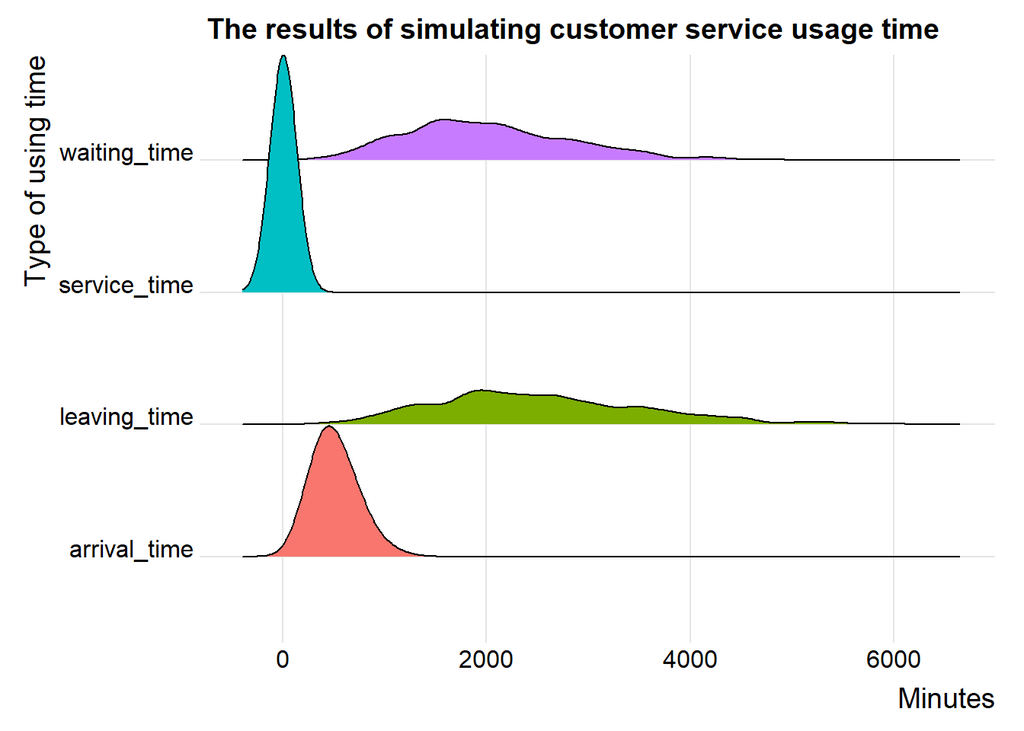

```r
#Plot the line represent the service time, waiting time, arrival time and leaving time:
library(ggridges)
library(viridis)
df2<-df1 %>%
  pivot_longer(cols = c("arrival_time","waiting_time","service_time","leaving_time"),
               names_to = "Type_of_time",
               values_to = "Minutes")

ggplot(data = df2,
       mapping = aes(x = Minutes,
                     y = as.factor(Type_of_time),
                     fill = Type_of_time
                     ))+
  geom_density_ridges() +
  theme_ridges() +
  theme(legend.position = "none")+
  labs(y = "Type of using time", x = "Minutes",
       title = "The results of simulating customer service usage time")
```